# Species contributions to robustness and functional diversity

We measure what each pollinator contributes to its community, to later ask with a structural equation model how much of that contribution depends on its network role (normalised degree) and its position in trait space (originality). We measure each pollinator’s contribution to:

1. the **robustness** of the network;
2. plant **functional diversity**.

## Robustness

Robustness $R$ is the area under the curve of the fraction of plants surviving as pollinators are removed one by one, a plant going extinct once all its pollinators are gone (Memmott et al. 2004). We average it over 1000 random removal orders. $R_i^\text{first}$ is the same average when pollinator $i$ is always removed first. The contribution of $i$ is

$$\Delta R_i = R - R_i^\text{first}$$

that is, how much less robust the network is when $i$ is lost first rather than an average pollinator (`compute_robustness_contributions()` in `R/contributions.R`).

```r
web_list <- tar_read(web_list)

robustness_contributions <- tar_read(robustness_contributions) |>
  left_join(
    tar_read(net_metrics) |>
      filter(guild == "pollinator") |>
      select(site, species, normalised_degree),
    by = join_by(site, species)
  ) |>
  group_by(site) |>
  mutate(n_pollinators = n()) |>
  ungroup() |>
  mutate(n_plants = vapply(web_list, nrow, integer(1))[site]) |>
  group_by(site) |>
  mutate(cascade_relative = (cascade - mean(cascade)) / n_plants) |>
  ungroup()

spearman <- function(x, y) sprintf("%.2f", cor(x, y, method = "spearman"))
```

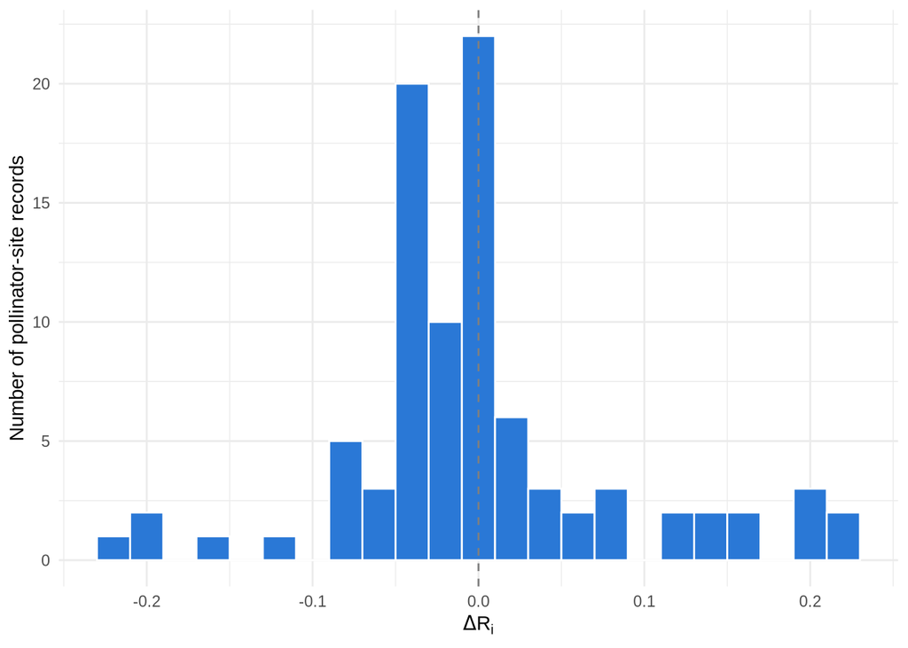

```r
ggplot(robustness_contributions, aes(x = delta_r_first)) +
  geom_histogram(
    binwidth = 0.02, fill = guild_colors[["pollinator"]], color = "white"
  ) +
  geom_vline(xintercept = 0, linetype = "dashed", color = "grey50") +
  labs(x = expression(Delta * R[i]), y = "Number of pollinator-site records")
```

**$\Delta R_i$ sums to zero within a site.** A random order can be drawn by picking the first pollinator (probability $1/n$ each) and shuffling the rest, so $R$ is the mean of the $R^\text{first}_i$:

$$R = \frac{1}{n} \sum_i R^\text{first}_i
\quad \Rightarrow \quad \sum_i \Delta R_i = 0$$

We estimate $R$ this way, so the sum is exactly zero. $\Delta R_i$ is thus relative: how much more a pollinator matters than the others at its site. At two-pollinator sites, the two species get opposite values.

```r
robustness_contributions |>
  filter(n_pollinators == 2) |>
  select(site, species, cascade, delta_r_first) |>
  mutate(delta_r_first = round(delta_r_first, 3)) |>
  knitr::kable(col.names = c("site", "species", "cascade", "ΔR"))
```

| site | species | cascade | ΔR |
| --- | --- | --- | --- |
| crocfrbir | a_mellifera | 2 | 0.000 |
| crocfrbir | l_sordidum | 2 | 0.000 |
| crocfrbou | b_terrestris | 5 | 0.167 |
| crocfrbou | o_varia | 1 | -0.167 |
| cromcctai | a_mellifera | 2 | 0.071 |
| cromcctai | l_sordidum | 0 | -0.071 |
| daigrelin | d_platura | 1 | 0.000 |
| daigrelin | p_marginata | 1 | 0.000 |
| daimusspr | a_mellifera | 4 | 0.200 |
| daimusspr | p_marginata | 0 | -0.200 |
| daiwarbro | a_mellifera | 6 | 0.214 |
| daiwarbro | p_marginata | 0 | -0.214 |
| garmottai | c_vicina | 0 | -0.200 |
| garmottai | d_platura | 4 | 0.200 |

**$\Delta R_i$ measures how much more plant species are lost after removing $i$ removal, compared with an average pollinator removal.** Let $\text{c}_i$ be the number of plants whose only pollinator is $i$, $\bar c$ its site average and $P$ the number of plants. When every plant has a single pollinator,

$$\Delta R_i = \frac{1}{2} \cdot \frac{\text{c}_i - \bar c}{P}.$$

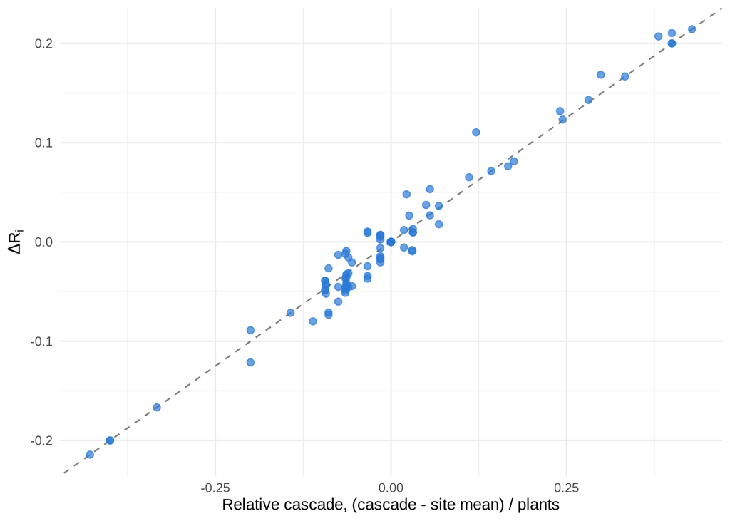

```r
ggplot(
  robustness_contributions,
  aes(x = cascade_relative, y = delta_r_first)
) +
  geom_abline(
    slope = 0.5, intercept = 0, linetype = "dashed", color = "grey50"
  ) +
  geom_point(size = 2, alpha = 0.7, color = guild_colors[["pollinator"]]) +
  labs(
    x = "Relative cascade, (cascade - site mean) / plants",
    y = expression(Delta * R[i])
  )
```

**Link with normalised degree.** $\Delta R_i$ rises with normalised degree (ρ = 0.70), as the degree → contribution path of the SEM expects.

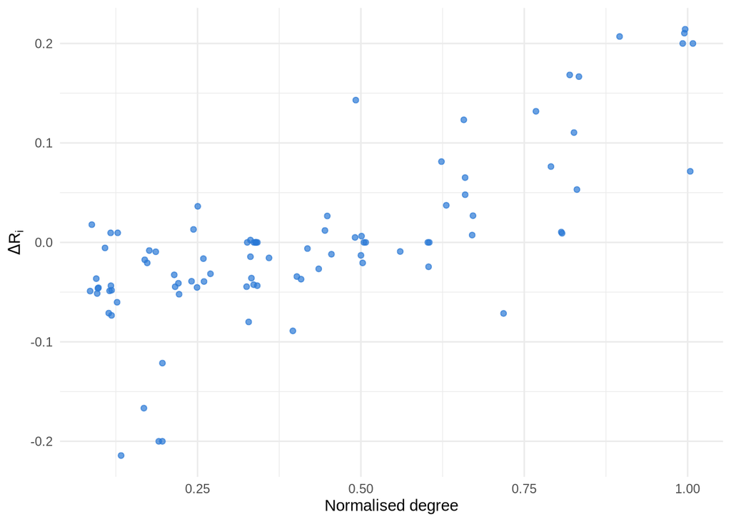

```r
ggplot(
  robustness_contributions,
  aes(x = normalised_degree, y = delta_r_first)
) +
  geom_jitter(
    width = 0.01, height = 0, alpha = 0.7, color = guild_colors[["pollinator"]]
  ) +
  labs(x = "Normalised degree", y = expression(Delta * R[i]))
```

## Contribution to functional diversity

We measure plant functional diversity (FD) with a dendrogram (Petchey and Gaston 2002): an average-linkage (UPGMA) tree of the 14 plant species in trait space, the same space as for originality. The FD of a set of plants is the total length of the branches connecting them, so a single plant has FD = 0. We build one tree for all sites, so branch lengths are comparable between sites.

Below, *P. marginata* is the only pollinator of *Lolium* at `daiburnam`. Losing it costs a third of the plants but half of the FD, because *Lolium* sits alone on a long branch.

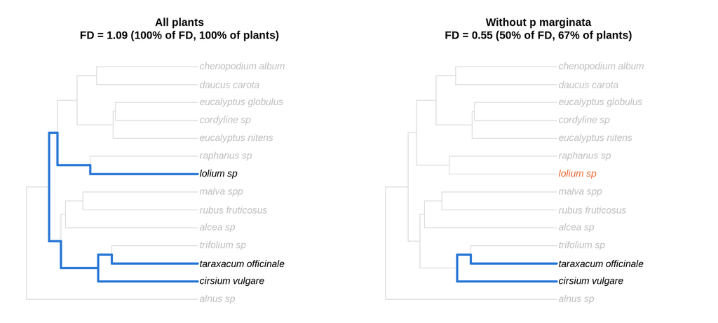

```r
plot_fd_removal(tar_read(plant_fd_tree), web_list[["daiburnam"]], "p_marginata")
```

We then repeat the robustness calculation with the fraction of the site’s plant FD retained instead of the fraction of plants alive. $\Delta FD_i$ is defined like $\Delta R_i$, with the same removal orders (`compute_fd_contributions()` in `R/contributions.R`). It also sums to zero within a site.

```r
contributions <- robustness_contributions |>
  left_join(tar_read(fd_contributions), by = join_by(site, species))
fd_fit <- lm(delta_fd_first ~ delta_r_first, contributions)
contributions <- contributions |>
  mutate(fd_residual = resid(fd_fit))
```

A pollinator removes FD only through the plants it alone visits, so $\Delta FD_i$ closely follows $\Delta R_i$ (R² = 0.97, slope = 1.10; dashed line 1:1 below). The slope is above 1 because the last plant has FD = 0, so FD falls faster than the number of plants. We use the residual of the regression, rather than the raw difference $\Delta FD_i - \Delta R_i$, so that it does not depend on $\Delta R_i$. It is positive when the plants $i$ supports are functionally distinct, and negative when they have functional equivalents at the site.

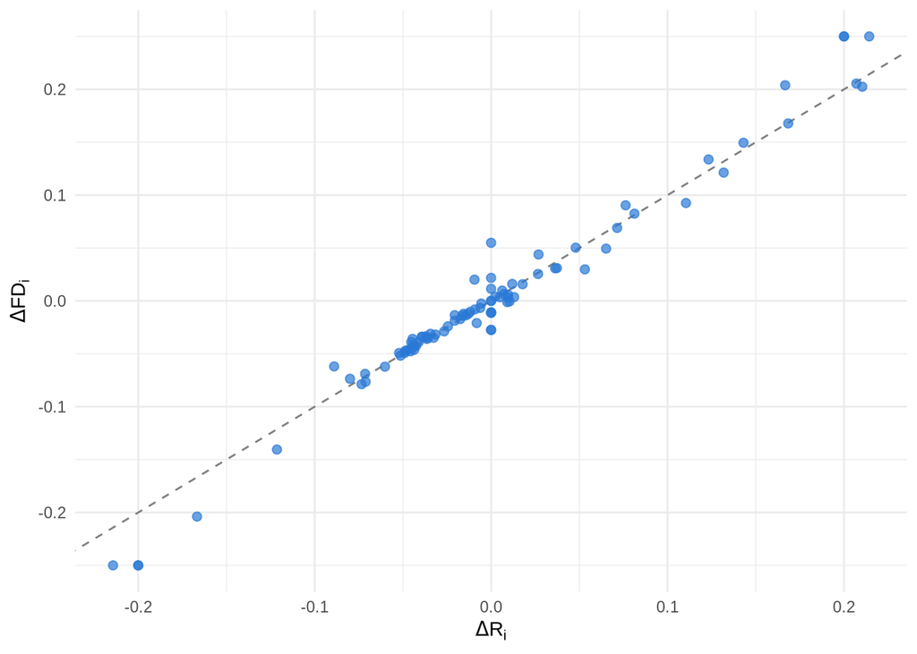

```r
ggplot(contributions, aes(x = delta_r_first, y = delta_fd_first)) +
  geom_abline(
    slope = 1, intercept = 0, linetype = "dashed", color = "grey50"
  ) +
  geom_point(size = 2, alpha = 0.7, color = guild_colors[["pollinator"]]) +
  labs(x = expression(Delta * R[i]), y = expression(Delta * FD[i]))
```

**What explains the residual?** The residual sums to zero within a site, so we correlate it with each candidate after subtracting the site mean. The candidates are the pollinator’s traits and network role, and the plants it supports (`compute_plant_support()`). Excess FD loss is the share of the site’s FD lost with the plants $i$ alone visits, minus the share of plants lost.

```r
residual_check <- contributions |>
  left_join(tar_read(plant_support), by = join_by(site, species)) |>
  left_join(
    tar_read(pollinator_trait_network) |>
      select(
        site, species, originality, originality_w, uniqueness, hs,
        abundance
      ),
    by = join_by(site, species)
  ) |>
  mutate(log_abundance = log(abundance))

candidates <- c(
  "Originality" = "originality",
  "Weighted originality" = "originality_w",
  "Uniqueness" = "uniqueness",
  "Normalised degree" = "normalised_degree",
  "HS" = "hs",
  "Abundance (log)" = "log_abundance",
  "Uniqueness of plants visited" = "partner_uniqueness",
  "Uniqueness of plants only it visits" = "sole_uniqueness",
  "Excess FD loss" = "excess_fd_loss"
)

residual_check |>
  group_by(site) |>
  mutate(across(all_of(unname(candidates)), \(x) x - mean(x, na.rm = TRUE))) |>
  ungroup() |>
  select(fd_residual, all_of(candidates)) |>
  pivot_longer(-fd_residual, names_to = "candidate") |>
  filter(!is.na(value), !is.na(fd_residual)) |>
  group_by(candidate = factor(candidate, names(candidates))) |>
  summarise(
    n = n(),
    rho = cor(fd_residual, value, method = "spearman"),
    p = cor.test(fd_residual, value, method = "spearman", exact = FALSE)$p.value
  ) |>
  mutate(across(c(rho, p), \(x) round(x, 3))) |>
  knitr::kable(col.names = c("Candidate", "n", "ρ", "p"))
```

| Candidate | n | ρ | p |
| --- | --- | --- | --- |
| Originality | 89 | -0.146 | 0.172 |
| Weighted originality | 89 | -0.107 | 0.317 |
| Uniqueness | 89 | -0.135 | 0.206 |
| Normalised degree | 90 | -0.177 | 0.096 |
| HS | 89 | 0.116 | 0.281 |
| Abundance (log) | 89 | -0.111 | 0.298 |
| Uniqueness of plants visited | 90 | 0.443 | 0.000 |
| Uniqueness of plants only it visits | 42 | 0.571 | 0.000 |
| Excess FD loss | 90 | 0.821 | 0.000 |

None of the pollinator’s own traits, nor its network role or abundance, predicts the residual. The traits of the plants it supports do: the residual is high when the plants a pollinator alone visits are functionally unique. Only pollinators with at least one such plant have a value for that candidate (n = 42). Excess FD loss is close to a restatement of the residual rather than an explanation of it. Among the explanatory candidates defined for all pollinators, the uniqueness of the plants visited is the best.

## Structural equation model

We ask how a pollinator’s traits shape its contribution to plant FD by going through the network. The variables sit on two axes, **trait space vs network** and **pollinator vs plant**:

|  | Pollinator | Plant |
| --- | --- | --- |
| **Trait space** | breadth, position | breadth and position of the plants visited |
| **Network** | normalised degree | $\Delta R_i$: the plants that depend on $i$ |

with $\Delta FD_i$ as the outcome: how many plants depend on $i$ ($\Delta R_i$), and which ones (their position). Paths only run along an axis:

- **down** (traits set network roles): a broad pollinator meets more plants, a peripheral one fewer; a narrow or peripheral plant has fewer pollinators, so it depends more on each;
- **across** (pollinators shape plants): a peripheral pollinator visits peripheral plants (trait matching); a narrow pollinator can only reach broad plants; the degree of a pollinator sets how many plants depend on it.

We take every trait from the Coux trait tables. **Breadth** is a single trait per guild, chosen *a priori* as the classic marker of generalism:

- **pollinators: sociality.** Social bees maintain colonies over a long season, so they forage across many flowering periods and collect from whatever flowers are open. Only *A. mellifera* and *B. terrestris* are social, so pollinator breadth here cannot be separated from these two species. Sociality also predicts normalised degree in these data, while body size, the other candidate (larger pollinators forage further), does not;
- **plants: inflorescence symmetry.** Radially symmetric (actinomorphic) inflorescences are open to many pollinators, whereas bilaterally symmetric (zygomorphic) ones restrict access to pollinators of matching shape and behaviour, the textbook marker of specialised pollination. We use the inflorescence, the unit pollinators land on, rather than the single flower: the heads of *Taraxacum*, *Cirsium* or *Trifolium* are made of zygomorphic florets but are open, radially symmetric resources.

Breadth could instead be measured from the interactions, as the trait diversity of a species’ partners. In these sparse networks this mostly measures degree: a species with a single partner has zero breadth, which is the case for a third of the pollinator records and half of the plants. Measured at the other sites, to break this circularity, it does not predict degree. **Position** is originality, for both guilds: the pollinator’s, and the mean of the plants it visits. Plant uniqueness explains $\Delta FD_i$ slightly better (see above), but in the model originality carries the link between pollinator and plant positions far better.

We fit a piecewise SEM (Lefcheck 2016), with one `glmmTMB` mixed model per response: binomial for normalised degree, Gaussian otherwise, with random effects of site and species, and correlated errors between the breadth and position of the plants visited (`fit_grid_sem()` in `R/sem.R`).

```r
sem_data <- tar_read(sem_data)
sem_summary <- tar_read(contribution_sem_summary)
sem_coefs <- sem_summary$coefficients
sem_est <- function(response, predictor) {
  row <- sem_coefs$Response == response & sem_coefs$Predictor == predictor
  p <- sem_coefs$P.Value[row]
  sprintf(
    "%+.2f, %s", sem_coefs$Std.Estimate[row],
    if (p < 0.001) "p < 0.001" else sprintf("p = %.3f", p)
  )
}

missing <- sem_summary$dTable
missing_p <- function(claim) {
  sprintf("%.2f", missing$P.Value[startsWith(missing$Independ.Claim, claim)])
}
```

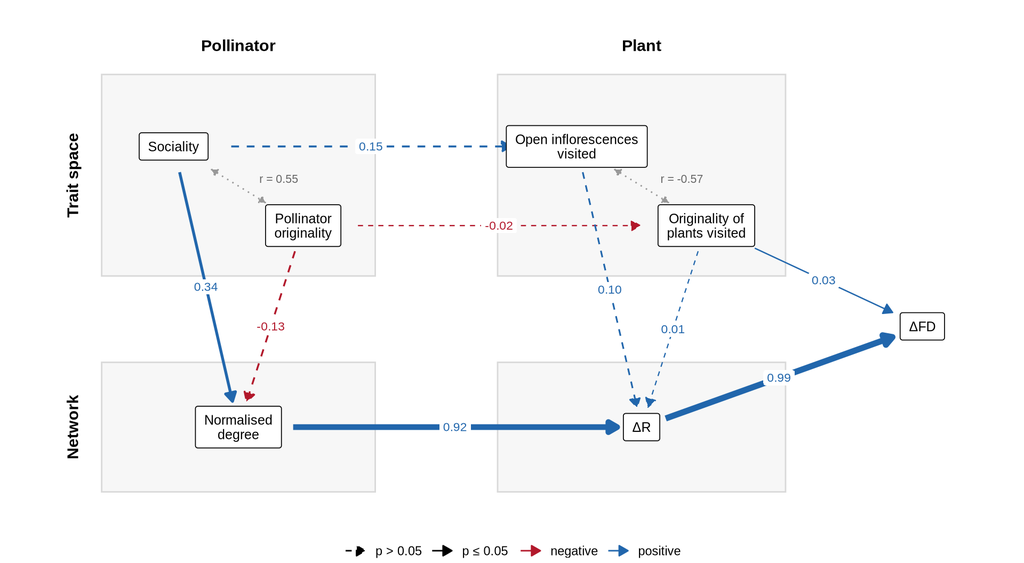

```r
plot_sem_paths(
  tar_read(contribution_sem), sem_data,
  breadth_label = "Sociality", plant_breadth_label = "Open inflorescences\nvisited"
)
```

Arrows show standardised coefficients (`plot_sem_paths()` in `R/sem.R`; 89 records, 16 species). The model fits (Fisher’s C = 24.9, df = 20, p = 0.21).

- **The network row works.** Social pollinators have a higher normalised degree (+0.34, p = 0.002), and degree sets how many plants depend on a pollinator (+0.92, p < 0.001), which carries most of $\Delta FD_i$ (+0.99, p < 0.001). Original pollinators tend to have a lower degree (-0.13, p = 0.064), as in the model.
- **The trait row fails.** Original pollinators do not visit original plants (-0.02, p = 0.875), and social pollinators visit actinomorphic flowers only weakly more (+0.15, p = 0.134).
- **The plant column is weak.** Visiting original plants raises $\Delta FD_i$ beyond $\Delta R_i$ (+0.03, p = 0.046), but the breadth of the plants visited does not change $\Delta R_i$ (+0.10, p = 0.209), whereas in the model narrow plants depend more on their pollinators.

One missing path is flagged, a direct, negative link from pollinator originality to $\Delta FD_i$ (p = 0.04): original pollinators contribute less to plant FD than their $\Delta R_i$ and plants predict. *A. mellifera* and *B. terrestris* are both the most original and the only social pollinators, and they concentrate on common plant types.

**Why the trait row fails.** The position argument needs a trait space shared by plants and pollinators, in which distance means “likely to interact”. The Coux traits describe each guild on its own (body size, diet, sociality; growth form, inflorescence, flowering season), and none were collected as matching pairs, such as tongue length and corolla depth. Pairing every pollinator trait with every plant trait, none predicts which pairs interact beyond chance (132 combinations, smallest adjusted p = 0.80). Phenology is the only dimension both guilds share, but each network was sampled within one flowering window, so it cannot show matching. Testing position thus requires matching traits measured on both guilds. With 16 species, two of them introduced social bees at the extreme of most axes, these data also have little power.

## References

Lefcheck, Jonathan S. 2016. “piecewiseSEM: Piecewise Structural Equation Modelling in R for Ecology, Evolution, and Systematics.” *Methods in Ecology and Evolution* 7 (5): 573–79. https://doi.org/10.1111/2041-210X.12512.

Memmott, Jane, Nickolas M. Waser, and Mary V. Price. 2004. “Tolerance of Pollination Networks to Species Extinctions.” *Proceedings of the Royal Society of London. Series B: Biological Sciences* 271 (1557): 2605–11. https://doi.org/10.1098/rspb.2004.2909.

Petchey, Owen L., and Kevin J. Gaston. 2002. “Functional Diversity (FD), Species Richness and Community Composition.” *Ecology Letters* 5 (3): 402–11. https://doi.org/10.1046/j.1461-0248.2002.00339.x.